# CourseProjectMachineLearning

Jaeyuel Park

## Objectives

The goal of your project is to predict the manner in which they did the exercise. This is the “classe” variable in the training set. You may use any of the other variables to predict with. You should create a report describing how you built your model, how you used cross validation, what you think the expected out of sample error is, and why you made the choices you did. You will also use your prediction model to predict 20 different test cases.

# About data

There are two datasets used for this analysis. Training set and test set. However, test set is not used in this file, for we need access to Coursera Project quiz. So we validate by creating another test using training set. Initially, there are 160 variables for both test and training sets. All of which are to explain HAR, human activity reaction. There are total 19622 observations in the training set and 20 for the test set. For further information about the data you could visit [here](http://groupware.les.inf.puc-rio.br/har)

# About model

The model we choose is random forest model. Although it is not included in this file, there were trials with gbm and decision tree as well. However, those two were not able to explain as well as random forest model. Resampling method is k fold, where k=5. Pre processing methods were not used.

## Loading and Exploratory Analysis on data

# Loading libraries

```r
library(ggplot2)
library(doParallel)
library(caret)
library(randomForest)
library(corrplot)
set.seed(1234)
```

# Links for the data

Download the files to the working directory for the analysis [Training set](https://d396qusza40orc.cloudfront.net/predmachlearn/pml-training.csv) [Test set](https://d396qusza40orc.cloudfront.net/predmachlearn/pml-testing.csv) [Information about the data](http://groupware.les.inf.puc-rio.br/har)

# Loading the Data

```r
pmltraining <- read.csv("pml-training.csv",na.strings = c("#DIV/0!", "NA"))
pmltesting  <- read.csv("pml-testing.csv",na.strings = c("#DIV/0!", "NA"))
```

## Exploratory Analysis & Cleaning data

```r
summary(pmltraining)
```

```
##        X          user_name         raw_timestamp_part_1 raw_timestamp_part_2
##  Min.   :    1   Length:19622       Min.   :1.322e+09    Min.   :   294
##  1st Qu.: 4906   Class :character   1st Qu.:1.323e+09    1st Qu.:252912
##  Median : 9812   Mode  :character   Median :1.323e+09    Median :496380
##  Mean   : 9812                      Mean   :1.323e+09    Mean   :500656
##  3rd Qu.:14717                      3rd Qu.:1.323e+09    3rd Qu.:751891
##  Max.   :19622                      Max.   :1.323e+09    Max.   :998801
##
##  cvtd_timestamp      new_window          num_window      roll_belt
##  Length:19622       Length:19622       Min.   :  1.0   Min.   :-28.90
##  Class :character   Class :character   1st Qu.:222.0   1st Qu.:  1.10
##  Mode  :character   Mode  :character   Median :424.0   Median :113.00
##                                        Mean   :430.6   Mean   : 64.41
##                                        3rd Qu.:644.0   3rd Qu.:123.00
##                                        Max.   :864.0   Max.   :162.00
##
##    pitch_belt          yaw_belt       total_accel_belt kurtosis_roll_belt
##  Min.   :-55.8000   Min.   :-180.00   Min.   : 0.00    Min.   :-2.121
##  1st Qu.:  1.7600   1st Qu.: -88.30   1st Qu.: 3.00    1st Qu.:-1.329
##  Median :  5.2800   Median : -13.00   Median :17.00    Median :-0.899
##  Mean   :  0.3053   Mean   : -11.21   Mean   :11.31    Mean   :-0.220
##  3rd Qu.: 14.9000   3rd Qu.:  12.90   3rd Qu.:18.00    3rd Qu.:-0.219
##  Max.   : 60.3000   Max.   : 179.00   Max.   :29.00    Max.   :33.000
##                                                        NA's   :19226
##  kurtosis_picth_belt kurtosis_yaw_belt skewness_roll_belt skewness_roll_belt.1
##  Min.   :-2.190      Mode:logical      Min.   :-5.745     Min.   :-7.616
##  1st Qu.:-1.107      NA's:19622        1st Qu.:-0.444     1st Qu.:-1.114
##  Median :-0.151                        Median : 0.000     Median :-0.068
##  Mean   : 4.334                        Mean   :-0.026     Mean   :-0.296
##  3rd Qu.: 3.178                        3rd Qu.: 0.417     3rd Qu.: 0.661
##  Max.   :58.000                        Max.   : 3.595     Max.   : 7.348
##  NA's   :19248                         NA's   :19225      NA's   :19248
##  skewness_yaw_belt max_roll_belt     max_picth_belt   max_yaw_belt
##  Mode:logical      Min.   :-94.300   Min.   : 3.00   Min.   :-2.10
##  NA's:19622        1st Qu.:-88.000   1st Qu.: 5.00   1st Qu.:-1.30
##                    Median : -5.100   Median :18.00   Median :-0.90
##                    Mean   : -6.667   Mean   :12.92   Mean   :-0.22
##                    3rd Qu.: 18.500   3rd Qu.:19.00   3rd Qu.:-0.20
##                    Max.   :180.000   Max.   :30.00   Max.   :33.00
##                    NA's   :19216     NA's   :19216   NA's   :19226
```

[output cut: 289 more lines]

```
##  Min.   :-446.00   Min.   :-1280.0   Min.   :-896.0   Min.   :-973.0
##  1st Qu.:-182.00   1st Qu.: -616.0   1st Qu.:   2.0   1st Qu.: 191.0
##  Median : -39.00   Median : -378.0   Median : 591.0   Median : 511.0
##  Mean   : -55.29   Mean   : -312.6   Mean   : 380.1   Mean   : 393.6
##  3rd Qu.:  26.00   3rd Qu.:  -73.0   3rd Qu.: 737.0   3rd Qu.: 653.0
##  Max.   : 291.00   Max.   :  672.0   Max.   :1480.0   Max.   :1090.0
##
##     classe
##  Length:19622
##  Class :character
##  Mode  :character
##
##
##
##
```

# Cleaning Data

We could check that there are indexing columns that could be removed(1). Also there are plenty of variables that are NAs(2). At last, there are some variables that seems likely to be NZV(3).

```r
##(1)cleaning indexing columns
pmltraining <- pmltraining[,-c(1:5)]
pmltesting <- pmltesting[,-c(1:5)]
##(2)Getting rid of NAs(Not imputing, but eliminating those that have too many NAs)
NAs    <- sapply(pmltraining, function(x) mean(is.na(x))) > 0.95
pmltraining <- pmltraining[,NAs==FALSE]
pmltesting <- pmltesting[,NAs==FALSE]
##(3)NZV
NZV <- nearZeroVar(pmltraining)
pmltraining <- pmltraining[,-NZV]
pmltesting <- pmltesting[,-NZV]
dim(pmltraining)
```

```
## [1] 19622    54
```

```r
dim(pmltesting)
```

```
## [1] 20 54
```

# Exploratory Anlalysis

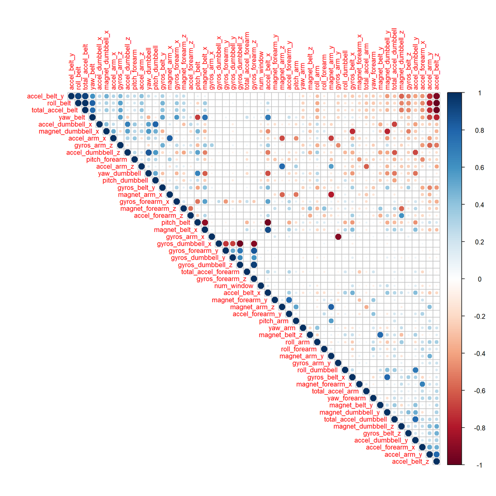

```r
#Correlations except for classe variable
corMatrix <- cor(pmltraining[,-54])
corrplot(corMatrix, type = "upper", method = "circle", order = "FPC", tl.cex=.8 )
```

```r
#"FPC" for the first principal component order
```

## Data Analysis & Building Model

# Creating training set

First we part training set, so we could validate within the given training set, and use the test set for the final testing purpose.

```r
intrain <- createDataPartition(pmltraining$classe, p=.7 , list = FALSE
                               )
training <- pmltraining[intrain,]
testing <-  pmltraining[-intrain,]
```

# Resampling method with parallel configuration

This part is for increasing the speed of the random forest. We here, set the method of resampling as k fold validation, where k = 5(10-fold and bootstrap takes too much time, although theres not so much of a difference in accuracy). With doparallel packages, it saves us lots of time with random forest model later.

```r
cluster <- makeCluster(detectCores() - 1)
registerDoParallel(cluster)
train.control <- trainControl(method = "cv", number = 5, allowParallel = TRUE)
```

# Training model

We are going to train the model with the random forest.

```r
rf<-train(classe ~., data = training, method = "rf", trControl = train.control)
stopCluster(cluster)
registerDoSEQ()
rf
```

```
## Random Forest
##
## 13737 samples
##    53 predictor
##     5 classes: 'A', 'B', 'C', 'D', 'E'
##
## No pre-processing
## Resampling: Cross-Validated (5 fold)
## Summary of sample sizes: 10989, 10991, 10989, 10991, 10988
## Resampling results across tuning parameters:
##
##   mtry  Accuracy   Kappa
##    2    0.9933755  0.9916201
##   27    0.9962872  0.9953037
##   53    0.9938853  0.9922651
##
## Accuracy was used to select the optimal model using the largest value.
## The final value used for the model was mtry = 27.
```

# Analyizing model

# Validation with testing set

```r
pre <- predict(rf, testing)
str(pre)
```

```
##  Factor w/ 5 levels "A","B","C","D",..: 1 1 1 1 1 1 1 1 1 1 ...
```

```r
str(testing$classe)
```

```
##  chr [1:5885] "A" "A" "A" "A" "A" "A" "A" "A" "A" "A" "A" "A" "A" "A" "A" ...
```

```r
confusionMatrix(pre, as.factor(testing$classe))
```

```
## Confusion Matrix and Statistics
##
##           Reference
## Prediction    A    B    C    D    E
##          A 1674    3    0    0    0
##          B    0 1135    6    0    0
##          C    0    1 1020    4    0
##          D    0    0    0  959    0
##          E    0    0    0    1 1082
##
## Overall Statistics
##
##                Accuracy : 0.9975
##                  95% CI : (0.9958, 0.9986)
##     No Information Rate : 0.2845
##     P-Value [Acc > NIR] : < 2.2e-16
##
##                   Kappa : 0.9968
##
##  Mcnemar's Test P-Value : NA
##
## Statistics by Class:
##
##                      Class: A Class: B Class: C Class: D Class: E
## Sensitivity            1.0000   0.9965   0.9942   0.9948   1.0000
## Specificity            0.9993   0.9987   0.9990   1.0000   0.9998
## Pos Pred Value         0.9982   0.9947   0.9951   1.0000   0.9991
## Neg Pred Value         1.0000   0.9992   0.9988   0.9990   1.0000
## Prevalence             0.2845   0.1935   0.1743   0.1638   0.1839
## Detection Rate         0.2845   0.1929   0.1733   0.1630   0.1839
## Detection Prevalence   0.2850   0.1939   0.1742   0.1630   0.1840
## Balanced Accuracy      0.9996   0.9976   0.9966   0.9974   0.9999
```

Accuracy is .9975, which, actually is higher than with the training set. So we can argue that it is well tuned. And out of sample error would be, .0025.